# Loan Data Analysis by Jack Bae

## Introduction

**Prosper** (www.prosper.com) is a peer-to-peer marketplace lending platform. Here is an explanation of Prosper from their website:

> Prosper allows people to invest in each other in a way that is financially and socially rewarding. On Prosper, borrowers list loan requests between $2,000 and $35,000 and individual investors invest as little as $25 in each loan listing they select. Prosper handles the servicing of the loan on behalf of the matched borrowers and investors.

And the process of how peer-to-peer lending at Prosper works:

> - Borrowers choose a loan amount, purpose and post a loan listing.
> - Investors review loan listings and invest in listings that meet their criteria.
> - Once the process is complete, borrowers make fixed monthly payments and investors receive a portion of those payments directly to their Prosper account.

The Prosper Loan data analyzed here contains 113,937 records last updated on 03/11/2014.

## Exploring the Dataset

The dataset contains 113937 records with 81 variables.

```
## [1] 113937     81
```

The names of the 81 variables:

```
##  [1] "ListingKey"
##  [2] "ListingNumber"
##  [3] "ListingCreationDate"
##  [4] "CreditGrade"
##  [5] "Term"
##  [6] "LoanStatus"
##  [7] "ClosedDate"
##  [8] "BorrowerAPR"
##  [9] "BorrowerRate"
## [10] "LenderYield"
## [11] "EstimatedEffectiveYield"
## [12] "EstimatedLoss"
## [13] "EstimatedReturn"
## [14] "ProsperRating..numeric."
## [15] "ProsperRating..Alpha."
```

[output cut: 66 more lines]

Overview of dataset variables:

```
##   ListingKey        ListingNumber     ListingCreationDate
##  Length:113937      Min.   :      4   Length:113937
##  Class :character   1st Qu.: 400919   Class :character
##  Mode  :character   Median : 600554   Mode  :character
##                     Mean   : 627886
##                     3rd Qu.: 892634
##                     Max.   :1255725
##
##  CreditGrade             Term        LoanStatus         ClosedDate
##  Length:113937      Min.   :12.00   Length:113937      Length:113937
##  Class :character   1st Qu.:36.00   Class :character   Class :character
##  Mode  :character   Median :36.00   Mode  :character   Mode  :character
##                     Mean   :40.83
##                     3rd Qu.:36.00
##                     Max.   :60.00
##
##   BorrowerAPR       BorrowerRate     LenderYield
##  Min.   :0.00653   Min.   :0.0000   Min.   :-0.0100
##  1st Qu.:0.15629   1st Qu.:0.1340   1st Qu.: 0.1242
##  Median :0.20976   Median :0.1840   Median : 0.1730
##  Mean   :0.21883   Mean   :0.1928   Mean   : 0.1827
##  3rd Qu.:0.28381   3rd Qu.:0.2500   3rd Qu.: 0.2400
##  Max.   :0.51229   Max.   :0.4975   Max.   : 0.4925
##  NA's   :25
##  EstimatedEffectiveYield EstimatedLoss   EstimatedReturn
##  Min.   :-0.183          Min.   :0.005   Min.   :-0.183
##  1st Qu.: 0.116          1st Qu.:0.042   1st Qu.: 0.074
##  Median : 0.162          Median :0.072   Median : 0.092
##  Mean   : 0.169          Mean   :0.080   Mean   : 0.096
##  3rd Qu.: 0.224          3rd Qu.:0.112   3rd Qu.: 0.117
##  Max.   : 0.320          Max.   :0.366   Max.   : 0.284
##  NA's   :29084           NA's   :29084   NA's   :29084
##  ProsperRating..numeric. ProsperRating..Alpha.  ProsperScore
##  Min.   :1.000           Length:113937         Min.   : 1.00
##  1st Qu.:3.000           Class :character      1st Qu.: 4.00
##  Median :4.000           Mode  :character      Median : 6.00
##  Mean   :4.072                                 Mean   : 5.95
##  3rd Qu.:5.000                                 3rd Qu.: 8.00
##  Max.   :7.000                                 Max.   :11.00
##  NA's   :29084                                 NA's   :29084
```

[output cut: 177 more lines]

```
##  Min.   :    0.00                Min.   :0.7000   Min.   : 0.00000
##  1st Qu.:    0.00                1st Qu.:1.0000   1st Qu.: 0.00000
##  Median :    0.00                Median :1.0000   Median : 0.00000
##  Mean   :   25.14                Mean   :0.9986   Mean   : 0.04803
##  3rd Qu.:    0.00                3rd Qu.:1.0000   3rd Qu.: 0.00000
##  Max.   :21117.90                Max.   :1.0125   Max.   :39.00000
##
##  InvestmentFromFriendsCount InvestmentFromFriendsAmount   Investors
##  Min.   : 0.00000           Min.   :    0.00            Min.   :   1.00
##  1st Qu.: 0.00000           1st Qu.:    0.00            1st Qu.:   2.00
##  Median : 0.00000           Median :    0.00            Median :  44.00
##  Mean   : 0.02346           Mean   :   16.55            Mean   :  80.48
##  3rd Qu.: 0.00000           3rd Qu.:    0.00            3rd Qu.: 115.00
##  Max.   :33.00000           Max.   :25000.00            Max.   :1189.00
##
```

While exploring the dataset, I found the need to create new variables and data frames. - New variables: ListingCreationYear, ListingCategoryName, CreditScoreAverage - New data frames: loansFrom2009 (loan data after July 12, 2009), loansTo2009 (loan data before July 12, 2009)

# Univariate Plots Section

### Is there a trend in the number of Prosper loans?

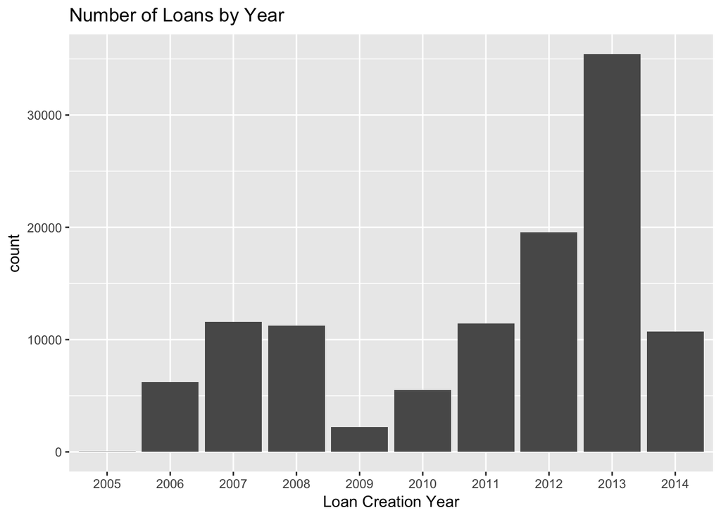

```
## [1] "2005-11-09 20:44:28.847000000" "2014-03-10 12:20:53.760000000"
```

Checking the range of loan listing creation date, the data confirms that the most recent data for 2014 is March 10, confirming 2014 data does not contain full year data.

### What is the distribution of loans by credit grade?

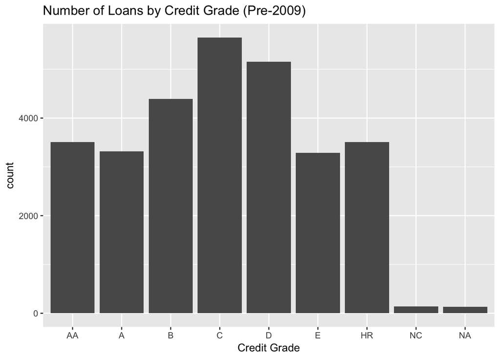

I was interested in investigating who uses peer-to-peer lending platform. One way of looking the data was throuth the credit grade that Prosper created. The credit grade data for data before July 12, 2009 shows a normal distribution of data. Prosper moved to a new rating system starting July 12, 2009.

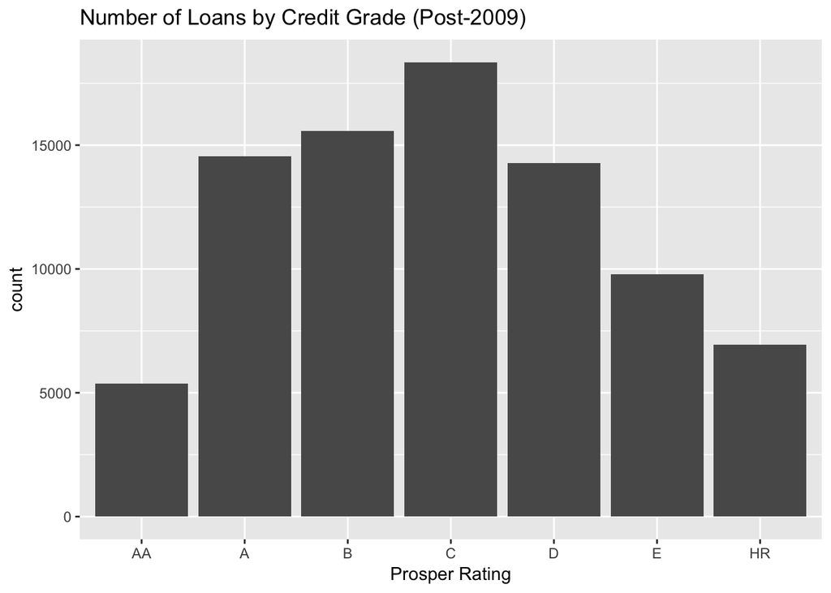

Post-2009 credit grade has been renamed as Prosper Rating. Although it is showing a normal distribution similar to pre-2009 credit grade distribution, the Prosper Rating is showing fewer applicants with the highest and the lowest distribution.

### Distribution of Credit Scores of Prosper Applicants

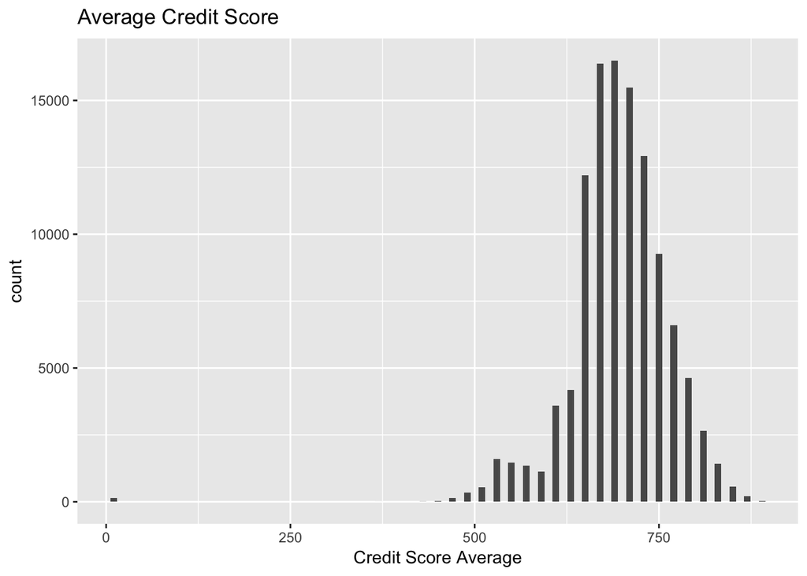

```
##    Min. 1st Qu.  Median    Mean 3rd Qu.    Max.    NA's
##    10.0   670.0   690.0   695.6   730.0   890.0     591
```

In further understanding Prosper applicants, I have plotted credit score of applicants. The dataset provided fields of lower and upper credit score range. The data here is the average of the lower and upper range.

According to study by [ValuePenguin](https://www.valuepenguin.com/average-credit-score), the average American credit score is 695, which is almost identical the score of 695.6 of Prosper applicants. This shows that Prosper applicants are not skewed towards either low or high credit score applicants. THe normal distribution of the plot further supports this finding.

### Distribution of risk score built by Prosper

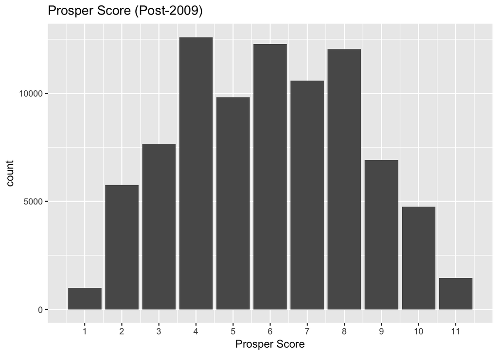

```
##    Min. 1st Qu.  Median    Mean 3rd Qu.    Max.    NA's
##    1.00    4.00    6.00    5.95    8.00   11.00   29084
```

The Prosper Score is a custom risk score built using historical Prosper data. The higher Prosper Score indicates the lowest risk users. The Prosper Score shows a different distribution from Prosper Rating data. This indicates the Prosper Score is calculated based on multiple factors.

### Distribution of loan term

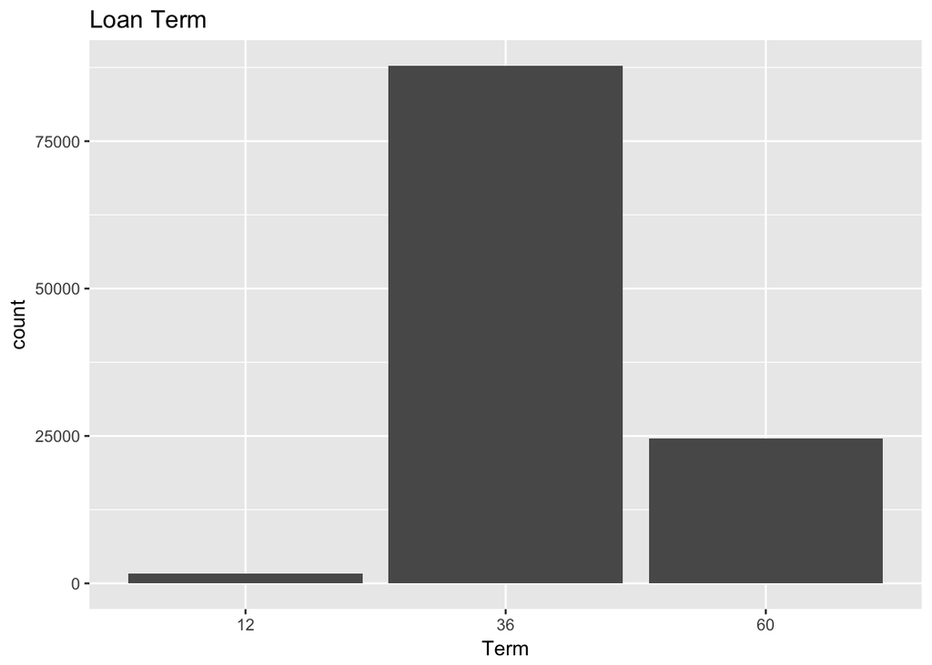

```
##
##    12    36    60
##  1614 87778 24545
```

After learning who used Prosper’s service, I was interested in how the Prosper lending service was used. The distribution of loan term shows that approximately 77% of the loans were 36 month loans. It is followed by 21.5% of 60 month loans and 1.5% of loans being 12 month loans.

### Distribution of Loan Status

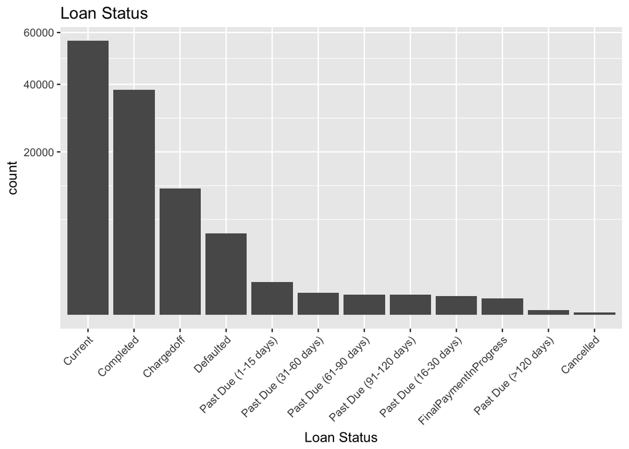

Next, I was interested in the current status of Prosper loans. Most of the loan status is current. It is followed by completed, charged off, and defaulted loan status.

### Distribution of Loans by Listing Category

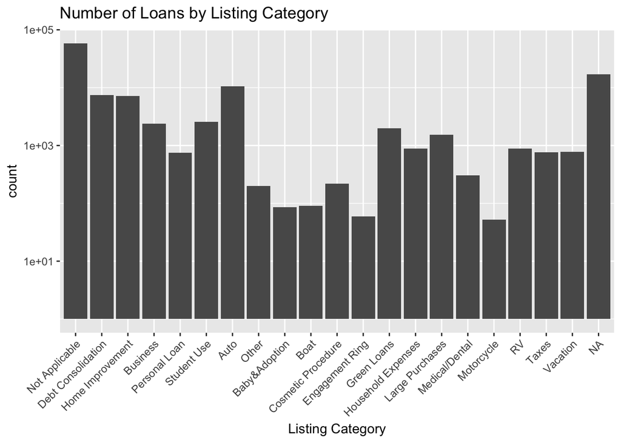

### Number of Current Credit Lines

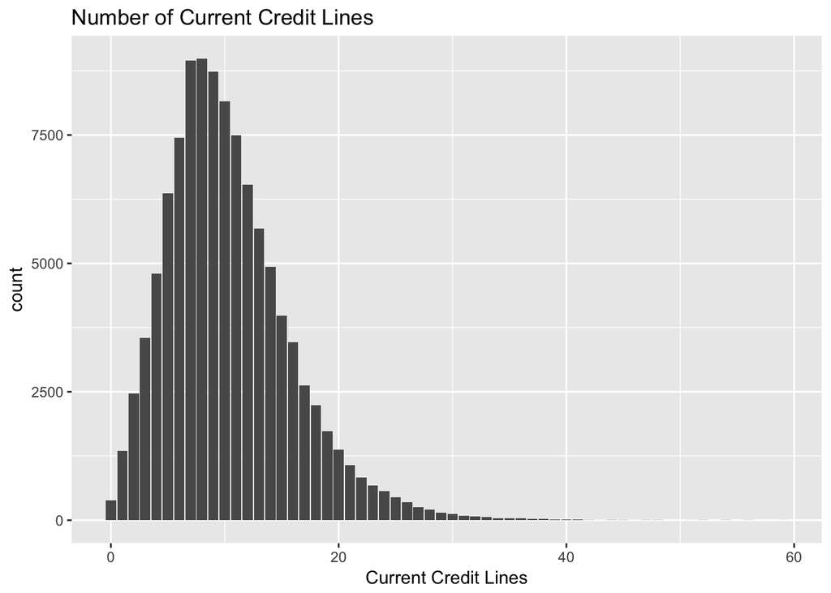

```
##    Min. 1st Qu.  Median    Mean 3rd Qu.    Max.    NA's
##    0.00    7.00   10.00   10.32   13.00   59.00    7604
```

The number of current credit lines at the time when credit profile was pulled ranges from 0 to 59, with average of 10.32.

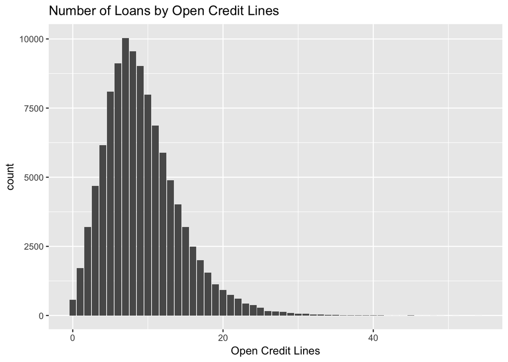

```
##    Min. 1st Qu.  Median    Mean 3rd Qu.    Max.    NA's
##    0.00    6.00    9.00    9.26   12.00   54.00    7604
```

The number of open credit lines at the time when credit profile was pulled shows a similar distribution with current credit lines. The number of loans by open credit lines ranges from 0 to 54, with average of 9.26.

### Number of Loans by Income Range

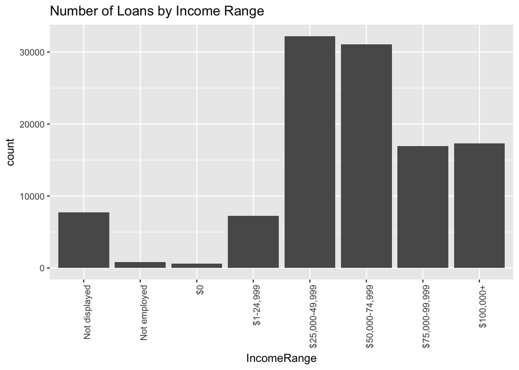

The income range data for borrowers show that the $25,000-49,999 income bracket request most loans, followed by $50,000-74,999 income range.

### Distribution of Total Prosper Loans

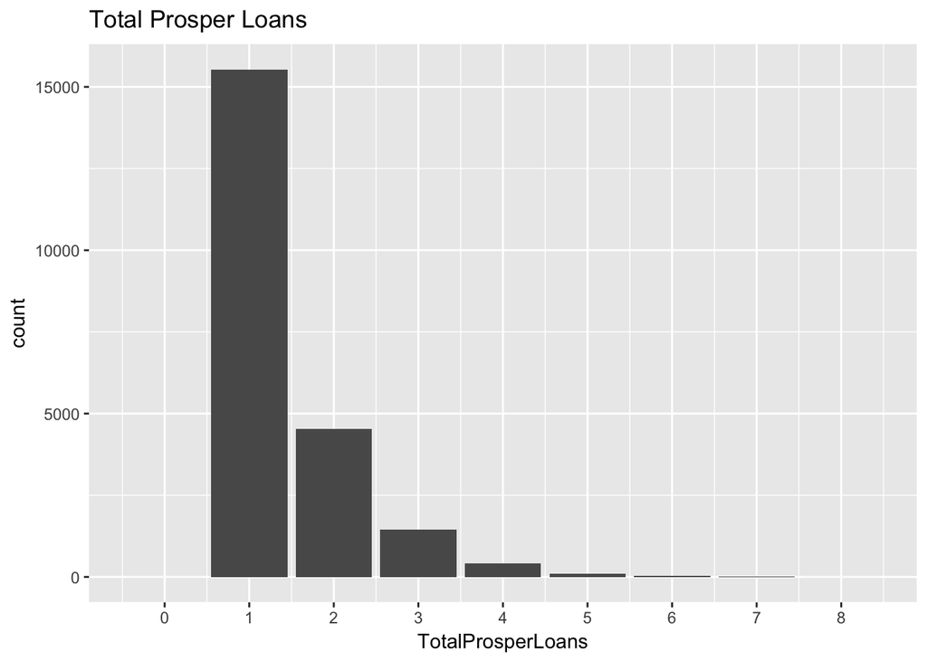

Data shows that most of the Prosper applicants were first-time borrowers. This was to be expected because of Prosper’s short history (founded in 2005).

### Distribution of Loan by Amount

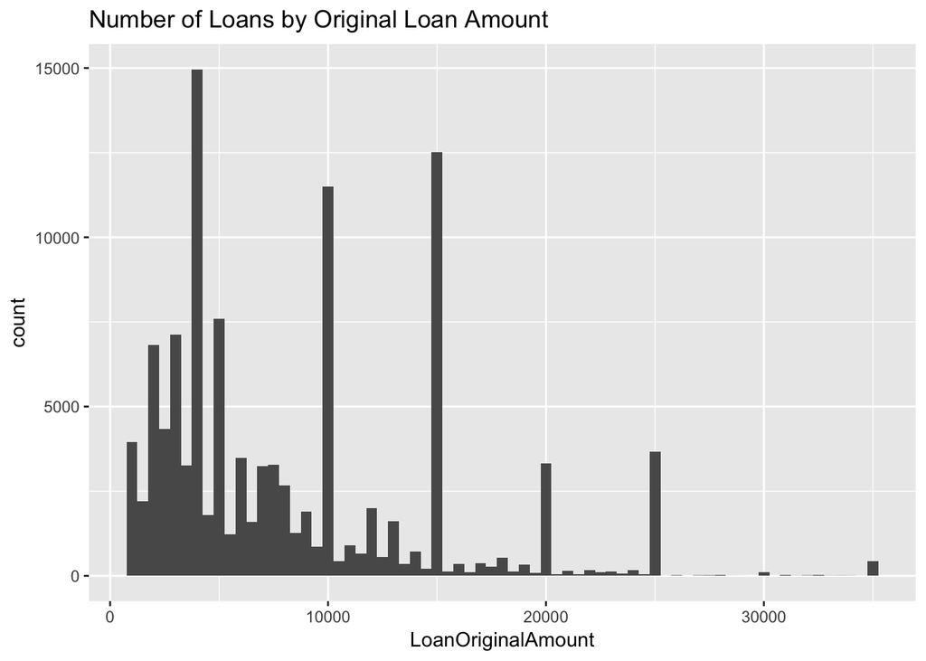

```
##    Min. 1st Qu.  Median    Mean 3rd Qu.    Max.
##    1000    4000    6500    8337   12000   35000
```

The distribution of loan amount shows a median amount of $6,500. The plot shows significant number of loans were increments of $5,000 with plots showing spikes in loan amount of $5,000, $10,000, $15,000, and $20,000.

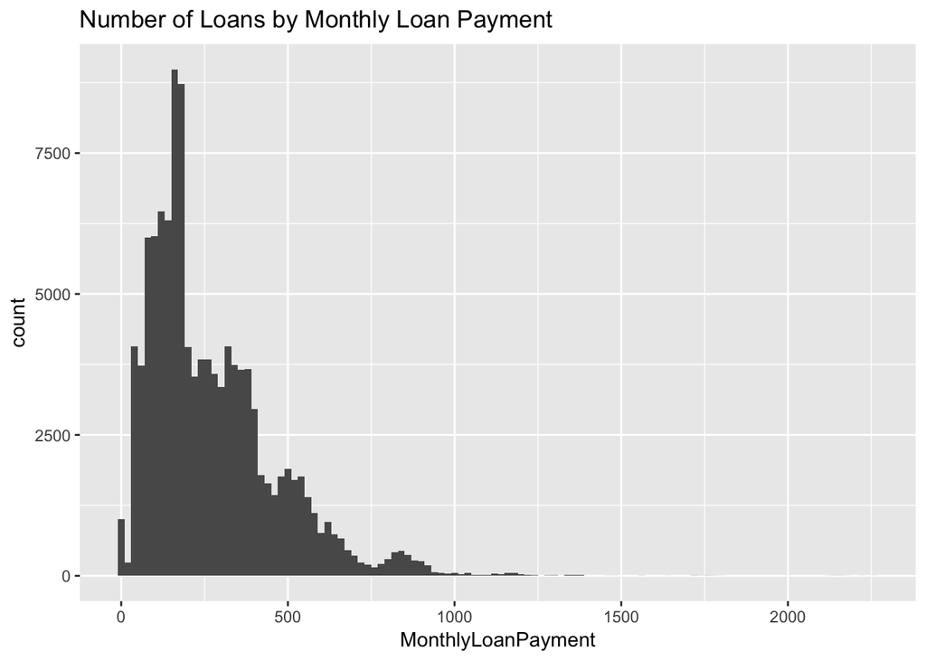

```
##    Min. 1st Qu.  Median    Mean 3rd Qu.    Max.
##     0.0   131.6   217.7   272.5   371.6  2251.5
```

The distribution of monthly loan payment shows median of $217.7. The plot shows most loan payment under $500 per month. With maximum payment of $2,251, this plot also shows flexibility in loan payment, which could be one factor in using Prosper loan service.

# Univariate Analysis

### What is the structure of your dataset?

The Prosper loan dataset contains 113,937 loan data across 81 variables.

### What is/are the main feature(s) of interest in your dataset?

In investigating the Prosper loan dataset, I was interested in who uses peer-to-peer lending service. The univariate plots revealed that many high income people used Prosper loan service. I was surprised and intrigued by this trend. I would like to investigate further categorize which people are more likely to take more loans and for what reason.

### What other features in the dataset do you think will help support your investigation into your feature(s) of interest?

In analysis of the dataset, I found the need to create a listing name for ListingCategory, where it originally had numerical values. Also, I found that the ListingCatoryYear would be helpful in seeing trends in listings year to year and CreditScoreAverage variable to have a single reference point for credit score instead of having a lower and upper range.

### Did you create any new variables from existing variables in the dataset?

I created ListingCreationYear, ListingCategoryName, and CreditScoreAverage variables to the dataset in assisting analyzing Prosper loan dataset.

### Of the features you investigated, were there any unusual distributions? Did you perform any operations on the data to tidy, adjust, or change the form of the data? If so, why did you do this?

It was interesting to see how much the 2009 Global financial crisis had impacted the number of Prosper loans initiated that year. I created ListingCreationYear to show prosper loan by year instead of showing continuous data variable.

# Bivariate Plots Section

### Prosper Rating vs Credit Score Average

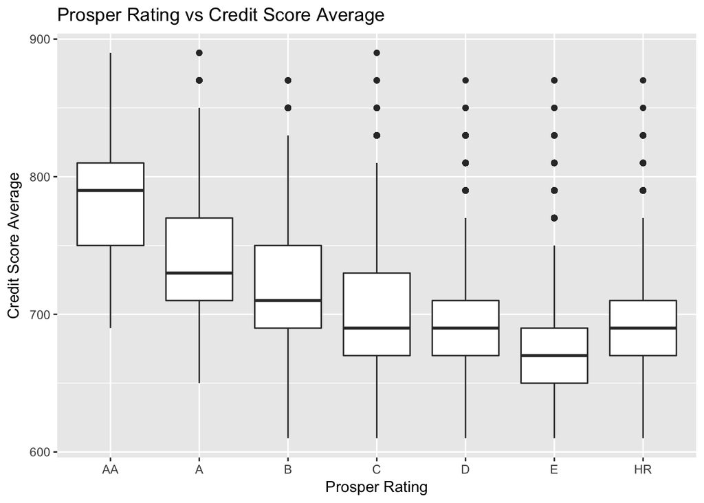

```
## loans$ProsperRating..Alpha.:
##    Min. 1st Qu.  Median    Mean 3rd Qu.    Max.    NA's
##    10.0   610.0   650.0   654.4   710.0   890.0     591
## --------------------------------------------------------
## loans$ProsperRating..Alpha.: A
##    Min. 1st Qu.  Median    Mean 3rd Qu.    Max.
##   650.0   710.0   730.0   739.9   770.0   890.0
## --------------------------------------------------------
## loans$ProsperRating..Alpha.: AA
##    Min. 1st Qu.  Median    Mean 3rd Qu.    Max.
##   690.0   750.0   790.0   784.1   810.0   890.0
## --------------------------------------------------------
## loans$ProsperRating..Alpha.: B
##    Min. 1st Qu.  Median    Mean 3rd Qu.    Max.
##   610.0   690.0   710.0   716.9   750.0   870.0
## --------------------------------------------------------
## loans$ProsperRating..Alpha.: C
##    Min. 1st Qu.  Median    Mean 3rd Qu.    Max.
##   610.0   670.0   690.0   699.9   730.0   890.0
## --------------------------------------------------------
## loans$ProsperRating..Alpha.: D
##    Min. 1st Qu.  Median    Mean 3rd Qu.    Max.
##   610.0   670.0   690.0   690.3   710.0   870.0
## --------------------------------------------------------
## loans$ProsperRating..Alpha.: E
##    Min. 1st Qu.  Median    Mean 3rd Qu.    Max.
##   610.0   650.0   670.0   672.5   690.0   870.0
## --------------------------------------------------------
## loans$ProsperRating..Alpha.: HR
##    Min. 1st Qu.  Median    Mean 3rd Qu.    Max.
##     610     670     690     687     710     870
```

### Prosper Rating vs Loan Original Amount

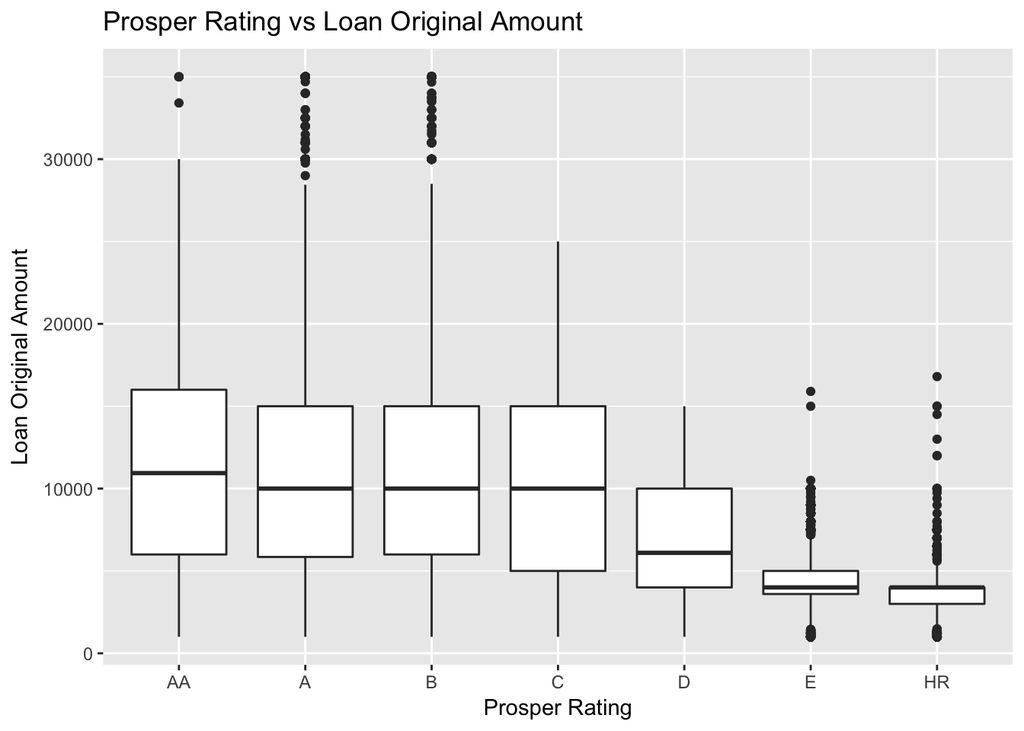

```
## loans$ProsperRating..Alpha.:
##    Min. 1st Qu.  Median    Mean 3rd Qu.    Max.
##    1000    2500    4500    6159    7904   25000
## --------------------------------------------------------
## loans$ProsperRating..Alpha.: A
##    Min. 1st Qu.  Median    Mean 3rd Qu.    Max.
##    1000    5850   10000   11460   15000   35000
## --------------------------------------------------------
## loans$ProsperRating..Alpha.: AA
##    Min. 1st Qu.  Median    Mean 3rd Qu.    Max.
##    1000    6000   10940   11584   16000   35000
## --------------------------------------------------------
## loans$ProsperRating..Alpha.: B
##    Min. 1st Qu.  Median    Mean 3rd Qu.    Max.
##    1000    6000   10000   11622   15000   35000
## --------------------------------------------------------
## loans$ProsperRating..Alpha.: C
##    Min. 1st Qu.  Median    Mean 3rd Qu.    Max.
##    1000    5000   10000   10392   15000   25000
## --------------------------------------------------------
## loans$ProsperRating..Alpha.: D
##    Min. 1st Qu.  Median    Mean 3rd Qu.    Max.
##    1000    4000    6100    7083   10000   15000
## --------------------------------------------------------
## loans$ProsperRating..Alpha.: E
##    Min. 1st Qu.  Median    Mean 3rd Qu.    Max.
##    1000    3600    4000    4586    5000   15900
## --------------------------------------------------------
## loans$ProsperRating..Alpha.: HR
##    Min. 1st Qu.  Median    Mean 3rd Qu.    Max.
##    1000    3000    4000    3463    4000   16800
```

The plot shows correlation between Prosper Rating and loan amount of applicants. Data shows that applicants with higher rating tend to have higher loans on Prosper.

### Listing Category vs Loan Original Amount

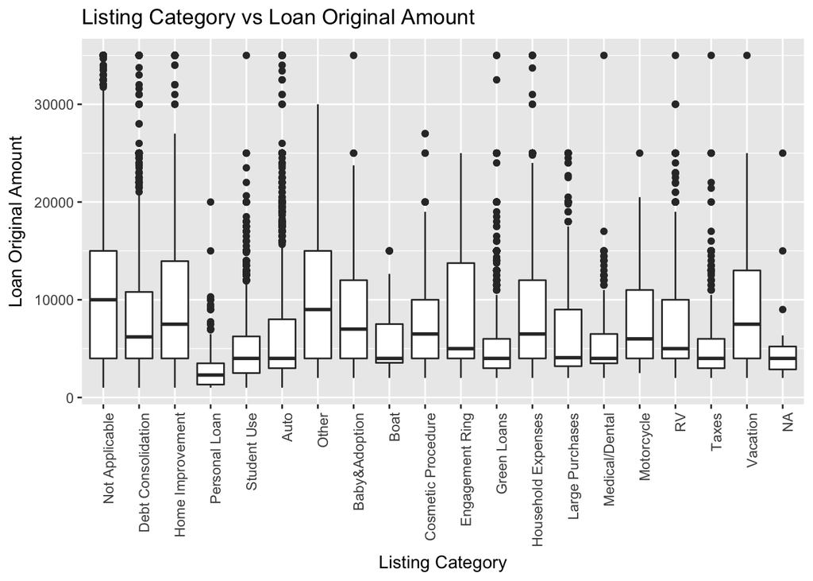

### Home Owner vs Loan Original Amount

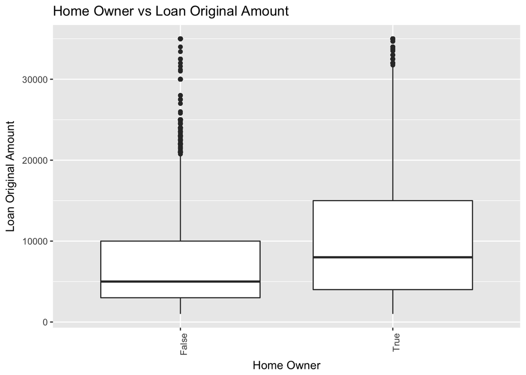

The data shows that homeowners have, on average, higher loan amount from Prosper.

# Bivariate Analysis

### Talk about some of the relationships you observed in this part of the investigation. How did the feature(s) of interest vary with other features in the dataset?

In investigating listing category vs. loan original amount data, I wass surprised to see listing category did not have a significant correlation with loan original amount. I expected greater variance with some category than others.

### Did you observe any interesting relationships between the other features (not the main feature(s) of interest)?

I observed that homeowner status has strong correlation with loan original amount.

### What was the strongest relationship you found?

The strongest relationship was prosper rating vs. credit score average. It was still surprising to learn that some people with high credit score still rated low on Prosper rating.

# Multivariate Plots Section

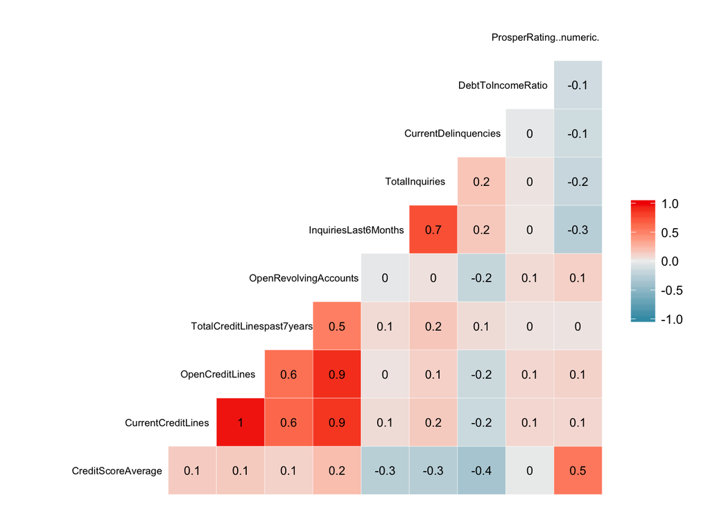

I was interested in learning which factors in the dataset has greatest correlation with each other and ultimately with the Prosper Rating. The heat map shows that the Pearson correlation between chosen variables for investigation. The Prosper Rating has greatest correlation with average credit score. It has little correlation with number of current credit lines, number of open credit lines, and number of revolving accounts.

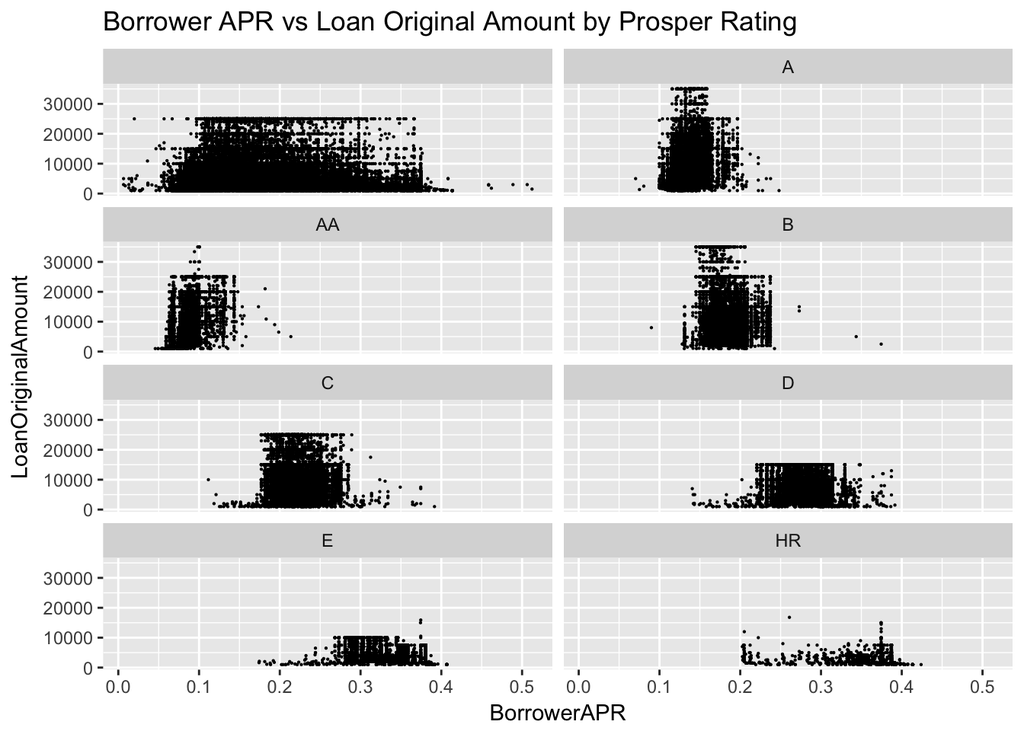

In this plot, I wanted to investigate how much loans people take depending on Prosper rating. As expected, higher credit raters enjoy lower APR. The plot shows that higher credit raters tends to take higher loans, while lower credit raters has more variance in APR even within Prosper rating bracket.

# Multivariate Analysis

### Talk about some of the relationships you observed in this part of the investigation. Were there features that strengthened each other in terms of looking at your feature(s) of interest?

In investigating subset of Prosper loan data, I was able to find that the average credit score had the strongest correlation.

In investigating Borrower APR vs Loan Original Amount by Prosper Rating I found that people with higher Prosper Rating are likely to have larger loans. I also found that the lower Prosper Rating users see more variation in APR even within their Prosper Rating bracket.

### Were there any interesting or surprising interactions between features?

I was surprised to see little correlation betewen number of credit accounts opened and Prosper Rating.

# Final Plots and Summary

### Plot One

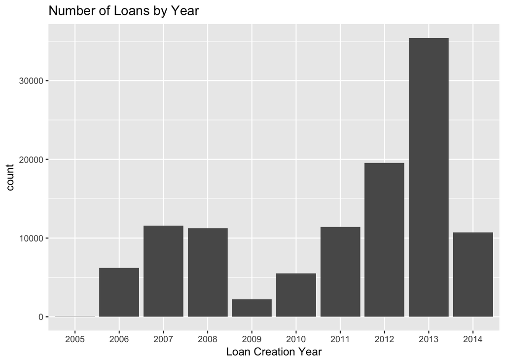

### Description One

This plot shows not only shows the growth of Prosper’s business but also the growth of peer-to-peer lending service. It is showing steady growth since 2005, with the exception of Global Finanical Crisis in 2009.

### Plot Two

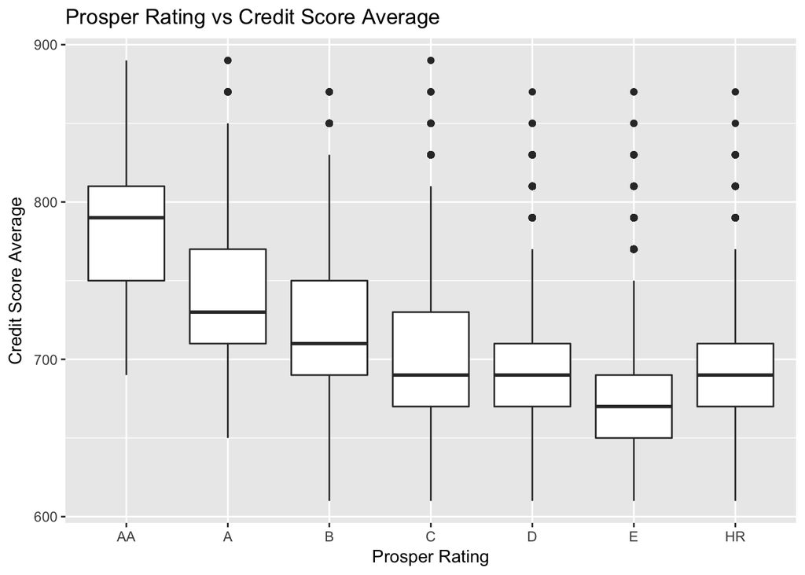

### Description Two

I was interested to see how Prosper rating is calculated. Although the Prosper Rating is strongly correlated with credit scores, I was also surprised to see lower Prosper Rating associated with high credit scores. This shows that Prosper Rating is calculated based on multiple factors.

### Plot Three

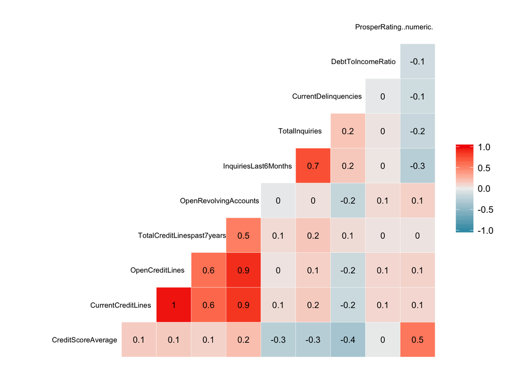

### Description Three

In continuation of investigating how Prosper Rating is calculated, I created a subset of data with the factors that could potentially have correlation with Prosper Rating. The credit score has the strongest correlation to Prosper Rating.

# Reflection

Investigating the Prosper Loan dataset, I gained insight into the peer-to-peer lending service. I had no idea on who used this service and the APR the users enjoyed. In investigating the dataset, I was most interested in who uses Prosper’s service, how they used the service, and for what purpose. The biggest struggle was first with the ggplot syntax and organizing plots so that it was easy for the user to interpret the data. The second major challenge for me was finding interesting trends from the dataset. Finding trends and relationships from 81 variables was a challenge with the number of variables and data. I found that by dividing the variables into similar and smaller pieces, I was able to decipher data more easily.

One interesting future work could be finding trends that could influence Prosper Rating. It is likely that the current Prosper Rating does not account for applicants based on economy situation. During a recession like 2009, there could be factors more relevant to risk factors than during an economic boom. Having a dynamic Prosper Rating based on economic sitaution could help filter applicants effectively and ultimately bring more profits to Prosper.